# 2020 Advent of Code - Day 1: Report Repair

## Intro

Advent of Code is an annual puzzle-solving project created by Eric Wastl. You can find out more about it here: https://adventofcode.com/2020/about.

I can't commit the time to completing all 50 puzzles this year, but where I can, I want to focus on clearly explaining the approach. This is for my own future benefit, and to make the solution more accessible to anyone who may be interested in taking a similar tack.

## Approach

Today's problem involves finding two values in a list that add up to a particular target, then multiplying those two values together. Here's my approach:

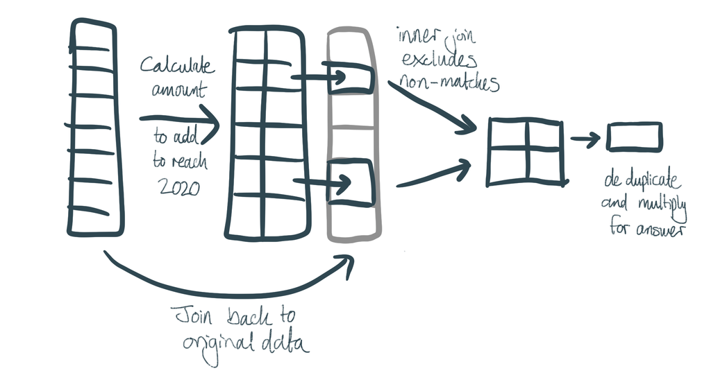

## Import packages and data

```r
library(tidyverse)
```

The problem description uses this list as an example:

```r
expenses <- c(1721, 979, 366, 299, 675, 1456)
```

## Process for solving the problem

Create a tibble from the data. The tibble will contain two columns: expenses and sumTo2020.

sumTo2020 is the value that would need to be added to the expense amount to total 2020.

```r
tbl_expenses <- tibble(expenses, sumTo2020 = 2020 - expenses)
```

| expenses | sumTo2020 |
| --- | --- |
| 1721 | 299 |
| 979 | 1041 |
| 366 | 1654 |
| 299 | 1721 |
| 675 | 1345 |
| 1456 | 564 |

We now need to check to see if any of the values in sumTo2020 were in the original expenses list.

We can do this by joining the two columns together using an inner join. Joins are more commonly used to join together two different datasets. But there's no reason why you can't join a dataset to itself, and it's a useful technique here.

Inner joins exclude rows that are unmatched on the joining key. In our case, it means that rows where the sumTo2020 value is not in the original expenses list will be excluded from the result.

```r
expenses_criteria <- tbl_expenses %>%
  inner_join(tbl_expenses, by = c("sumTo2020" = "expenses")) %>%
  select(names(tbl_expenses))
```

| expenses | sumTo2020 |
| --- | --- |
| 1721 | 299 |
| 299 | 1721 |

Nearly there, but we have two many observations, as each one is repeated. We need to delete one of them.

In this example we could simply take the one with the smaller expense value, but what if there are multiple instances of values that add up to 2020? We need something to identify that these two rows are part of a pair.

```r
expenses_group <- expenses_criteria %>%
  mutate(id = str_c(pmin(expenses, sumTo2020),"-",pmax(expenses, sumTo2020)))
```

| expenses | sumTo2020 | id |
| --- | --- | --- |
| 1721 | 299 | 299-1721 |
| 299 | 1721 | 299-1721 |

Now we can drop one row for each id, and multiply the columns together to get the required answer.

```r
expenses_answer <- expenses_group %>%
  group_by(id) %>%
  top_n(1, expenses) %>%
  ungroup() %>%
  mutate(answer = expenses * sumTo2020)
```

| expenses | sumTo2020 | id | answer |
| --- | --- | --- | --- |
| 1721 | 299 | 299-1721 | 514579 |

## Automating the solution

To apply the solution to other datasets (and other years, presumably!) it's helpful to turn the above into a function.

Now that we're going to be completing the steps in one go, we can simplify the code by making more use of the pipe to combine multiple steps, avoiding some of the intermediate tables created for demonstration purposes.

```r
repairReport <- function(expenses, target){
  # This function takes a string of values and selects only the pairs that add up to a specific target amount

  stopifnot(is.numeric(expenses))
  stopifnot(is.numeric(target))
  stopifnot(length(target) == 1)

  tbl_expenses <- tibble(expenses, sumToTarget = target - expenses)

  result <- tbl_expenses %>%
    # Keep only observations where sumToTarget value is also in the original expenses report
    inner_join(tbl_expenses, by = c("sumToTarget" = "expenses")) %>%
    select(names(tbl_expenses)) %>%
    # Create id for deduplicating
    mutate(id = str_c(pmin(expenses, sumToTarget),"-",pmax(expenses, sumToTarget))) %>%
    group_by(id) %>%
    top_n(1, expenses) %>%
    ungroup() %>%
    # Calculate answer
    mutate(answer = expenses * sumToTarget) %>%
    # Format nicely as a table
    kable()

  return(result)
}
```

Let's test...

```r
repairReport(expenses, 2020)
```

| expenses | sumToTarget | id | answer |
| --- | --- | --- | --- |
| 1721 | 299 | 299-1721 | 514579 |

## Beware 1010

What would happen if 1010 was one of the values in the expense report?

```r
expenses_1010 <- c(expenses, 1010)
repairReport(expenses_1010, 2020)
```

| expenses | sumToTarget | id | answer |
| --- | --- | --- | --- |
| 1721 | 299 | 299-1721 | 514579 |
| 1010 | 1010 | 1010-1010 | 1020100 |

Since the sumToTarget value is technically also in the Expense report, it meets the inner join criteria and is kept as part of the answer.

However, the problem asked for the **two entries** that sum to 2020. So, a single value of 1010 should really be excluded from the answer. This could easily be achieved by removing observations where the expenses value is exactly half of the target.

It's also possible that 1010 could appear twice in the report, in which case the pair of 1010s should be included. So a different approach could be to instead exclude ids that only appear once.

We can do this by adding `filter(n() > 1)` after the `group_by(id)` operation.

```r
repairReport <- function(expenses, target){
  # This function takes a string of values and selects only the pairs that add up to a specific target amount

  stopifnot(is.numeric(expenses))
  stopifnot(is.numeric(target))
  stopifnot(length(target) == 1)

  tbl_expenses <- tibble(expenses, sumToTarget = target - expenses)

  result <- tbl_expenses %>%
    # Keep only observations where sumToTarget value is also in the original expenses report
    inner_join(tbl_expenses, by = c("sumToTarget" = "expenses")) %>%
    select(names(tbl_expenses)) %>%
    # Create id for deduplicating
    mutate(id = str_c(pmin(expenses, sumToTarget),"-",pmax(expenses, sumToTarget))) %>%
    group_by(id) %>%
    # Remove ids with only one entry - to handle single values that are exactly half of the target value
    filter(n() > 1) %>%
    # Deduplicate remaining ids
    top_n(1, expenses) %>%
    ungroup() %>%
    # Calculate answer
    mutate(answer = expenses * sumToTarget) %>%
    # Format nicely as a table
    kable()

  return(result)
}

repairReport(expenses_1010, 2020)
```

| expenses | sumToTarget | id | answer |
| --- | --- | --- | --- |
| 1721 | 299 | 299-1721 | 514579 |

```r
expenses_dbl_1010 <- c(expenses, 1010, 1010)
repairReport(expenses_dbl_1010, 2020)
```

| expenses | sumToTarget | id | answer |
| --- | --- | --- | --- |
| 1721 | 299 | 299-1721 | 514579 |
| 1010 | 1010 | 1010-1010 | 1020100 |
| 1010 | 1010 | 1010-1010 | 1020100 |
| 1010 | 1010 | 1010-1010 | 1020100 |
| 1010 | 1010 | 1010-1010 | 1020100 |

Something's still not right here!

Because in this example 1010 appears twice in expenses, each occurence in sumToTarget will link to both rows in expenses. In all there will be 4 connections, so the result has 4 rows.

`top_n(1, expenses)` won't help us here, as all 4 rows tie as the top value. It seems `top_n()` is being retired in favour of `slice_min()/slice_max()` anyway. My version of dplyr predates `slice_min()/slice_max()`, but `slice()` worked fine too.

```r
repairReport <- function(expenses, target){
  # This function takes a string of values and selects only the pairs that add up to a specific target amount

  stopifnot(is.numeric(expenses))
  stopifnot(is.numeric(target))
  stopifnot(length(target) == 1)

  tbl_expenses <- tibble(expenses, sumToTarget = target - expenses)

  result <- tbl_expenses %>%
    # Keep only observations where sumToTarget value is also in the original expenses report
    inner_join(tbl_expenses, by = c("sumToTarget" = "expenses")) %>%
    select(names(tbl_expenses)) %>%
    # Create id for deduplicating
    mutate(id = str_c(pmin(expenses, sumToTarget),"-",pmax(expenses, sumToTarget))) %>%
    group_by(id) %>%
    # Remove ids with only one entry - to handle single values that are exactly half of the target value
    filter(n() > 1) %>%
    # Deduplicate remaining ids by taking first entry in each grouping
    slice(1) %>%
    ungroup() %>%
    # Calculate answer
    mutate(answer = expenses * sumToTarget) %>%
    # Format nicely as a table
    kable()

  return(result)
}

repairReport(expenses_1010, 2020)
```

| expenses | sumToTarget | id | answer |
| --- | --- | --- | --- |
| 1721 | 299 | 299-1721 | 514579 |

```r
expenses_dbl_1010 <- c(expenses, 1010, 1010)
repairReport(expenses_dbl_1010, 2020)
```

| expenses | sumToTarget | id | answer |
| --- | --- | --- | --- |
| 1010 | 1010 | 1010-1010 | 1020100 |
| 1721 | 299 | 299-1721 | 514579 |